# *hyperSpec* Plotting Functions

# 10 Using *ggplot2* with *hyperSpec* objects

Class `hyperSpec` objects do not yet directly support plotting with package **ggplot2**[7]. Nevertheless, package **ggplot2** graphics can easily be obtained, and `qplot*` equivalents to `plotspc()` and `plotmap()`.

## 10.1 Function `qplotspc()`

Plot spectra with `qplotspc()` (Fig. 10.1).

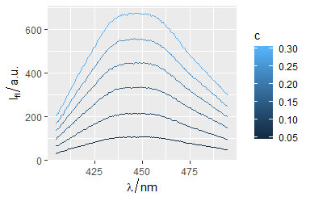

```r
qplotspc(flu) + aes(colour = c)
```

Fig. 10.2 shows a map created with package **ggplot2**.

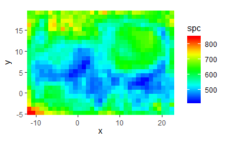

Figure 10.2: False-colour map with package **ggplot2**

```r
qplotmap(chondro) +
    scale_fill_gradientn("spc", colours = matlab.palette())
```

The two special columns `.wavelength` and `.rownames` contain the wavelength axis and allow to distinguish the spectra.

## 10.3 More General Plotting with *ggplot2*

For more general plotting, `as.long.df()` transforms a `hyperSpec` object into a long-form `data.frame` that is suitable for `qplot()`, while `as.t.df()` produces a `data.frame` where each spectrum is one column, and an additional first column gives the wavelength. Long `data.frame`s can be *very* memory consuming as they are of size $nrow · nwl × (ncol + 2)$ with respect to the dimensions of the `hyperSpec` object. Thus, e.g., the `chondro` data set (2 MB) as `hyperSpec` object) needs 28 MB as long-format `data.frame`. It is therefore highly recommended to calculate the particular data to be plotted beforehand (Fig. 10.3).

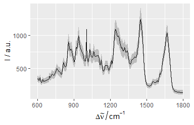

Figure 10.3: Mean $\pm$ standard deviation with package **ggplot2**.

```r
qplotspc(mean(chondro)) +
  geom_ribbon(aes(
    ymin = mean + sd,
    ymax = mean - sd,
    y = 0,
    group = NA
  ),
    alpha = 0.25,
    data = as.t.df(mean_sd(chondro))
  )
```

Note that `qpotspc()` specifies aesthetics `y = spc` and `groups = .rownames`, which do not have corresponding columns in the `data.frame` returned by `as.t.df()`. These aesthetics must therefore be set manually in the aesthetics definition in `geom_ribbon()` (or any other `geom_*()` that uses `as.t.df()`). Otherwise, errors occur that object `spc` (and/or `.rownames`) cannot be found. Cut axes can be implemented by faceting (Fig. 10.4).

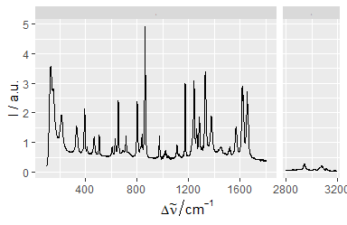

Figure 10.4: Cut spectra with package **ggplot2**.

```r
qplotspc(paracetamol / 1e4, wl.range = c(min ~ 1800, 2800 ~ max)) +
  scale_x_continuous(breaks = seq(0, 3200, 400))
```

# 11 Interactive Graphics

Package **hyperSpec** offers basic interaction, `spc.identify()` for spectra plots, and `map.identify()` and `map.sel.poly()` for maps. The first two identify points in spectra plots and map plots, respectively. Function `map.sel.poly()` selects the part of a `hyperSpec` object that lies inside the user defined polygon.

## 11.1 `spc.identify()` Finding Out Wavelength, Intensity and Spectrum

Function `spc.identify()` allows to measure points in graphics produced by `plotspc()`. It works correctly with reversed and cut wavelength axes.

```r
spc.identify(plotspc(paracetamol, wl.range = c(600 ~ 1800, 2800 ~ 3200), xoffset = 800))
```

The result is a data.frame with the indices of the spectra, the wavelength, and its intensity.

## 11.2 `map.identify()` finding a spectrum in a map plot

Function `map.identify()` returns the spectra indices of the clicked points.

```r
map.identify(chondro)
```

## 11.3 `map.sel.poly()` selecting spectra inside a polygon in a map plot

Function `map.sel.poly()` returns a logical indicating which spectra are inside the polygon drawn by the user:

```r
map.sel.poly(chondro)
```

## 11.4 Related Functions Provided by Base Graphics and *lattice*

For base graphics (as produced by `plotspc()`), `locator()` may be useful as well. It returns the clicked coordinates. Note that these are *not* transformed according to `xoffset` & Co.

For lattice graphics, `grid.locator()` may be used instead. If it is not called in the panel function, a preceding call to `trellis.focus()` is needed:

```r
plot(laser, "mat")
trellis.focus()
grid.locator()
```

Function `identify()` (or `panel.identify()` for lattice graphics) allows to identify points of the plot directly. Note that the returned indices correspond to the plotted object.

# 12 Troubleshooting

## 12.1 No Output Is Produced

Methods `plotmap`, `plotvoronoi`, `levelplot`, and `plotc` use package **lattice** functions. Therefore, in loops, functions, Sweave chunks, etc. the lattice object needs to be printed explicitly by `print(plotmap(object))` ([R FAQ: Why do lattice/trellis graphics not work?](http://cran.r-project.org/doc/FAQ/R-FAQ.html#Why-do-lattice_002ftrellis-graphics-not-work_003f)). The same holds for package **ggplot2** graphics.

For suggestions on how the lattice functions can be redefined so that the result is printed without external print command, see the file `vignettes.defs`.

# References

[1] D. Sarkar, Lattice: Multivariate data visualization with r, Springer, New York, 2008. http://lmdvr.r-forge.r-project.org.

[2] L. J, Plotrix: A package in the red light district of r, R-News. 6 (2006) 8–12.

[3] D. Sarkar, F. Andrews, LatticeExtra: Extra graphical utilities based on lattice, 2019. https://CRAN.R-project.org/package=latticeExtra.

[4] R. Turner, Deldir: Delaunay triangulation and dirichlet (voronoi) tessellation, 2019. https://CRAN.R-project.org/package=deldir.

[5] F. code by R. J. Renka. R functions by Albrecht Gebhardt. With contributions from Stephen Eglen <stephen@anc.ed.ac.uk>, S. Zuyev, D. White, Tripack: Triangulation of irregularly spaced data, 2016. https://CRAN.R-project.org/package=tripack.

[6] D. Adler, D. Murdoch, others, Rgl: 3D visualization using opengl, 2019. https://CRAN.R-project.org/package=rgl.

[7] H. Wickham, Ggplot2: Elegant graphics for data analysis, Springer-Verlag New York, 2016. https://ggplot2.tidyverse.org.